# Kaggle Competiton: Titanic

Yuzhe Zhao

12/19/2020

# Content

1. Introduction
2. Data Preparation
   1. Load data & Overview
   2. Exploratory data analysis (EDA)
      1. Table analysis
         1. Survival rate & Sex
         2. Survival rate & Embarked
         3. Survival rate & Passenger class
         4. Survival rate & Family size
      2. Chart analysis
         1. Survival rate & Age
         2. Survival rate & Fare
   3. Data cleansing
      1. Correct faulty values
         1. Correct ticket price values
      2. Impute missing values
         1. Fill the missing values in Embarked and Fare with modes and median
         2. Fill the missing values in Age based on Pclass
         3. Delete the Cabin feature as there are too many missing values
      3. Feature engineering
         1. Create ticket letter feature, which represent the alphabets in Tickets
         2. Create Family Size feature, which is the number of SibSp + the number of Parch + 1
         3. Create IsAlone feature, which represent whether the people do not have family members' accompany
         4. Create the title feature, which represent the title of name
         5. Create bins feature for Age and Fare
      4. Convert data types
      5. Delete meaningless variables
   4. Draw correlation chart
3. Modeling
   1. Split data into datasets
   2. Choose best models for ensemble
   3. Hyper Parameter Tuning
   4. Ensemble Models by hard and soft voting
4. Prediction and Submission

# Introduction

## Problem Statement

At 2:20 a.m. on April 15, 1912, the luxury cruise liner Titanic sank in the North Atlantic Ocean after running into an iceberg at around 11:40 p.m. on April 14, 1912. More than 1500 of the estimated 2,224 passengers and crew aboard died in this disaster, making the sinking at the time the deadliest of a single ship in the West.

In the process of compiling the data of the passengers on the Titanic, people found that the probability of survival was different for people with different features. In another word, there are some people have a better chance of survival than others.

Therefore, in this article, we are going to use the data of passengers to build machine learning models to answer the question that "what sorts of people were more likely to survive". We are going to use the data that provided by Kaggle, here is the link of the competition and data: https://www.kaggle.com/c/titanic.

```python
# Load packages
import sys
print("Python version: {}". format(sys.version))

import pandas as pd
print("pandas version: {}". format(pd.__version__))

import datatable as dt
print("datatable version: {}".format(dt.__version__))

import matplotlib
print("matplotlib version: {}". format(matplotlib.__version__))

import numpy as np
print("numpy version: {}".format(np.__version__))

import scipy as sp
print("scipy version: {}".format(sp.__version__))

import IPython
print("IPython version: {}". format(IPython.__version__))

import sklearn
print("scikit-learn version: {}".format(sklearn.__version__))

import graphviz
print("graphviz version: {}".format(graphviz.__version__))

import random
import time

import warnings
warnings.filterwarnings('ignore')
print("-"*25)
```

```
Python version: 3.8.2 (default, Mar 26 2020, 10:43:30)
[Clang 4.0.1 (tags/RELEASE_401/final)]
pandas version: 1.1.3
```

```
datatable version: 0.11.1
matplotlib version: 3.3.2
numpy version: 1.19.2
scipy version: 1.5.2
IPython version: 7.19.0
scikit-learn version: 0.23.2
graphviz version: 0.15
-------------------------
```

```python
#Common Model Algorithms
from sklearn import svm, tree, linear_model, neighbors, naive_bayes, ensemble, discriminant_analysis, gaussian_process
from xgboost import XGBClassifier

#Common Model Helpers
from sklearn.preprocessing import OneHotEncoder, LabelEncoder
from sklearn import feature_selection
from sklearn import model_selection
from sklearn import metrics
from sklearn.model_selection import learning_curve
from sklearn.ensemble import VotingClassifier, AdaBoostClassifier, BaggingClassifier, GradientBoostingClassifier, RandomForestClassifier
from sklearn.linear_model import LogisticRegressionCV
from sklearn.discriminant_analysis import LinearDiscriminantAnalysis, QuadraticDiscriminantAnalysis
from sklearn.neighbors import KNeighborsClassifier
from sklearn.tree import DecisionTreeClassifier

#Visualization
import matplotlib as mpl
import matplotlib.pyplot as plt
import matplotlib.pylab as pylab
import seaborn as sns
from pandas.plotting import scatter_matrix

#Configure Visualization Defaults
#%matplotlib inline = show plots in Jupyter Notebook Browser
%matplotlib inline
mpl.style.use('ggplot')
sns.set_style('white')
pylab.rcParams['figure.figsize'] = 12,8
```

# Data Preparation

## Load data & Overview

There are two datasets: train.csv and test.csv. There are 12 features with 891 entries in the train dataset and 11 features with 418 entries in the test dataset. The train.csv dataset has one more feature about whether the passenger survived.

Here is the illustration of the means of all features:

1. PassengerId is the unique id of passengers.
2. Survived is whether the passenger survived: 1 = Survived 0 = Not Survived
3. Pclass is the passenger class (1st, 2nd, 3rd), which is a proxy of socio-economic class: 1 = Upper Class 2 = Middle Class 3 = Lower Class
4. Name is the passengers' name with titles.
5. Sex: female = female male = male
6. Age
7. SibSp is the number of the passengers' siblings and spouse that were on board
8. Parch is the number of the passengers' parents and children that were on board
9. Ticket is the ticket Id
10. Fare is the ticket prices
11. Cabin is the cabin number of the passenger
12. Embarked is the place that the passenger embarked: C = Cherbourg Q = Queenstown S = Southampton

```python
#Load data

#1) For Kaggle Notebooks:
#train_data_raw = pd.read_csv("../input/titanic/train.csv")
#test_data_raw = pd.read_csv("../input/titanic/test.csv")
#2) For Jupyter Notebooks:
train_data_raw = pd.read_csv("titanic/train.csv")
test_data_raw = pd.read_csv("titanic/test.csv")
```

```python
#Overview

#1)Column, Non-Null Count, DataType
print(train_data_raw.info())
print(test_data_raw.info())
print('-'*20)

#2)Choose one from the three methods
#print(train_data_raw.head()) #head
#print(train_data_raw.tail()) #tail
print(train_data_raw.sample(10)) #randomly sample 10 rows
print(test_data_raw.sample(10))
print('-'*20)
```

[output not shown]

# Exploratory data analysis (EDA)

## Table analysis:

In this stage, we are going to use tables to explore whether discrete/categorical variables have effects on survival rate.

In this section, we got the following insights:

```python
#Exploratory data analysis (EDA)

#1) Table analysis:

#a) A little feature engineering for exploration

train_data_raw['FamilySize'] = train_data_raw['SibSp'] + train_data_raw['Parch'] + 1

#b) List variable datatypes for EDA
categorical_variables = ['Sex','Embarked']
discrete_variables = ['Pclass','FamilySize']
continuous_variables = ['Age','Fare']
```

```python
#c) Explore whether discrete/categorical variables have effects on survival rate
for i in range(len(categorical_variables)):
    print(train_data_raw[[categorical_variables[i], 'Survived']].groupby([categorical_variables[i]], as_index=False).mean().sort_values(by='Survived', ascending=False))
for i in range(len(discrete_variables)):
    print(train_data_raw[[discrete_variables[i], 'Survived']].groupby([discrete_variables[i]], as_index=False).mean().sort_values(by=discrete_variables[i], ascending=True))
```

```
      Sex  Survived
0  female  0.742038
1    male  0.188908
  Embarked  Survived
0        C  0.553571
1        Q  0.389610
2        S  0.336957
   Pclass  Survived
0       1  0.629630
1       2  0.472826
2       3  0.242363
   FamilySize  Survived
0           1  0.303538
1           2  0.552795
2           3  0.578431
3           4  0.724138
4           5  0.200000
5           6  0.136364
6           7  0.333333
7           8  0.000000
8          11  0.000000
```

## Chart analysis:

In this section, we got the following insights:

1. The number of survived infants is larger than died ones. The number of survived people in their 20-30s are smaller than died ones.
2. The survival rate for people who bought tickets with high prices is larger than people who bought tickets with low prices.

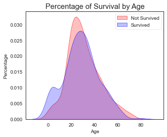

```python
#1) Chart analysis: Explore whether continuous numerical variables have effects on survival rate

#a) Age & Survival rate
plt.figure(figsize=(5,4))
g = sns.kdeplot(train_data_raw["Age"][(train_data_raw["Survived"] == 0) & (train_data_raw["Age"].notnull())], color="Red", shade = True)
g = sns.kdeplot(train_data_raw["Age"][(train_data_raw["Survived"] == 1) & (train_data_raw["Age"].notnull())], ax =g, color="Blue", shade= True)
g.set_xlabel("Age",fontsize=10)
g.set_ylabel("Percentage",fontsize=10)
g.set_title('Percentage of Survival by Age',fontsize=15)
g = g.legend(["Not Survived","Survived"],fontsize=10)
plt.show()
```

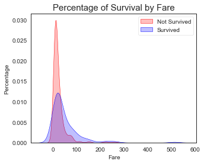

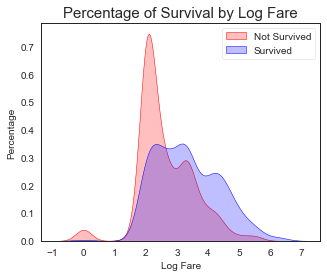

```python
#b) LogFare & Survival rate

#Non-log Fare
plt.figure(figsize=(5,4))
g = sns.kdeplot(train_data_raw["Fare"][(train_data_raw["Survived"] == 0) & (train_data_raw["Fare"].notnull())], color="Red", shade = True)
g = sns.kdeplot(train_data_raw["Fare"][(train_data_raw["Survived"] == 1) & (train_data_raw["Fare"].notnull())], ax =g, color="Blue", shade= True)
g.set_xlabel("Fare",fontsize=10)
g.set_ylabel("Percentage",fontsize=10)
g.set_title('Percentage of Survival by Fare',fontsize=15)
g = g.legend(["Not Survived","Survived"],fontsize=10)
plt.show()
#Log Fare
plt.figure(figsize=(5,4))
train_data_raw["FareLog"] = train_data_raw["Fare"].map(lambda i: np.log(i) if i > 0 else 0)
g = sns.kdeplot(train_data_raw["FareLog"][(train_data_raw["Survived"] == 0) & (train_data_raw["FareLog"].notnull())], color="Red", shade = True)
g = sns.kdeplot(train_data_raw["FareLog"][(train_data_raw["Survived"] == 1) & (train_data_raw["FareLog"].notnull())], ax =g, color="Blue", shade= True)
g.set_xlabel("Log Fare",fontsize=10)
g.set_ylabel("Percentage",fontsize=10)
g.set_title('Percentage of Survival by Log Fare',fontsize=15)
g = g.legend(["Not Survived","Survived"],fontsize=10)
plt.show()
```

```python
# Cleaning the features for EDA, because they will not be used later.
drop_column_explore = ['FamilySize','FareLog']
train_data_raw.drop(drop_column_explore, axis=1, inplace=True)
train_data_raw.info()
```

```
<class 'pandas.core.frame.DataFrame'>
RangeIndex: 891 entries, 0 to 890
Data columns (total 12 columns):
 #   Column       Non-Null Count  Dtype
---  ------       --------------  -----
 0   PassengerId  891 non-null    int64
 1   Survived     891 non-null    int64
 2   Pclass       891 non-null    int64
 3   Name         891 non-null    object
 4   Sex          891 non-null    object
 5   Age          714 non-null    float64
 6   SibSp        891 non-null    int64
 7   Parch        891 non-null    int64
 8   Ticket       891 non-null    object
 9   Fare         891 non-null    float64
 10  Cabin        204 non-null    object
 11  Embarked     889 non-null    object
dtypes: float64(2), int64(5), object(5)
memory usage: 83.7+ KB
```

```python
# Fun fact: We can conclude that Jack will most likely die and Rose will most likely survive.
```

# Data Cleansing

In this section, we will,

1. Draw the correlation chart to see the correlation among variables.
2. Correcting faulty values.
   1. Correct ticket prices
3. Imputing missing values.
   1. Fill the missing value in Embarked, Fare, Age columns.
   2. Delete the Cabin variable.
4. Creating new features by feature engineering.
   1. Create ticket letter feature, which represent the alphabets in Tickets.
   2. Create Family Size feature, which is the number of SibSp + the number of Parch + 1.
   3. Create IsAlone feature, which represent whether the people do not have family members' accompany.
   4. Create the title feature, which represent the title of name.
   5. Create bins feature for Age and Fare.

## Correlation chart:

```python
#Join train and test datasets
train_len = len(train_data_raw)
dataset = pd.concat(objs=[train_data_raw, test_data_raw], axis=0).reset_index(drop=True)
dataset.info()
```

```
<class 'pandas.core.frame.DataFrame'>
RangeIndex: 1309 entries, 0 to 1308
Data columns (total 12 columns):
 #   Column       Non-Null Count  Dtype
---  ------       --------------  -----
 0   PassengerId  1309 non-null   int64
 1   Survived     891 non-null    float64
 2   Pclass       1309 non-null   int64
 3   Name         1309 non-null   object
 4   Sex          1309 non-null   object
 5   Age          1046 non-null   float64
 6   SibSp        1309 non-null   int64
 7   Parch        1309 non-null   int64
 8   Ticket       1309 non-null   object
 9   Fare         1308 non-null   float64
 10  Cabin        295 non-null    object
 11  Embarked     1307 non-null   object
dtypes: float64(3), int64(4), object(5)
memory usage: 122.8+ KB
```

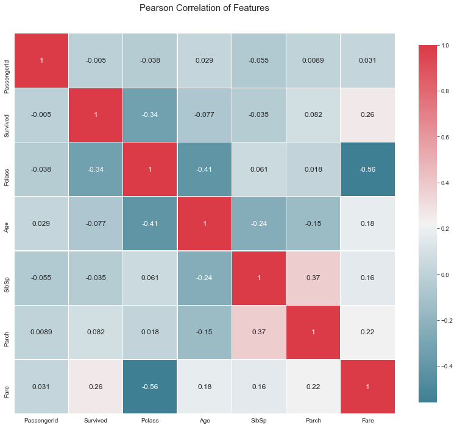

```python
# See correlation among features

def correlation_heatmap(df):
    _ , ax = plt.subplots(figsize =(14, 12))
    colormap = sns.diverging_palette(220, 10, as_cmap = True)

    _ = sns.heatmap(
        df.corr(),
        cmap = colormap,
        square=True,
        cbar_kws={'shrink':.9 },
        ax=ax,
        annot=True,
        linewidths=0.1,vmax=1.0, linecolor='white',
        annot_kws={'fontsize':12 }
    )

    plt.title('Pearson Correlation of Features', y=1.05, size=15)

correlation_heatmap(dataset)
```

## Correct ticket price values

There are two types of tickets: individual tickets and group tickets. In the following analysis, we will find that some people's ticket prices are abnormally high because the Fare data shows the group ticket price, rather than the individual ticket price. We will replace the group ticket prices with ticket price per person.

```python
#We can see these people share the same ticket prices, it is abnormal for people in 3rd-class have a fare of 69.55

print(dataset['Ticket'].value_counts())
dataset.loc[dataset["Ticket"]=='CA. 2343' ,:]
```

```
CA. 2343        11
1601             8
CA 2144          8
PC 17608         7
S.O.C. 14879     7
                ..
335677           1
3701             1
112053           1
W./C. 14258      1
392092           1
Name: Ticket, Length: 929, dtype: int64
```

|  | PassengerId | Survived | Pclass | Name | Sex | Age | SibSp | Parch | Ticket | Fare | Cabin | Embarked |
| --- | --- | --- | --- | --- | --- | --- | --- | --- | --- | --- | --- | --- |
| 159 | 160 | 0.0 | 3 | Sage, Master. Thomas Henry | male | NaN | 8 | 2 | CA. 2343 | 69.55 | NaN | S |
| 180 | 181 | 0.0 | 3 | Sage, Miss. Constance Gladys | female | NaN | 8 | 2 | CA. 2343 | 69.55 | NaN | S |
| 201 | 202 | 0.0 | 3 | Sage, Mr. Frederick | male | NaN | 8 | 2 | CA. 2343 | 69.55 | NaN | S |
| 324 | 325 | 0.0 | 3 | Sage, Mr. George John Jr | male | NaN | 8 | 2 | CA. 2343 | 69.55 | NaN | S |
| 792 | 793 | 0.0 | 3 | Sage, Miss. Stella Anna | female | NaN | 8 | 2 | CA. 2343 | 69.55 | NaN | S |
| 846 | 847 | 0.0 | 3 | Sage, Mr. Douglas Bullen | male | NaN | 8 | 2 | CA. 2343 | 69.55 | NaN | S |
| 863 | 864 | 0.0 | 3 | Sage, Miss. Dorothy Edith "Dolly" | female | NaN | 8 | 2 | CA. 2343 | 69.55 | NaN | S |
| 1079 | 1080 | NaN | 3 | Sage, Miss. Ada | female | NaN | 8 | 2 | CA. 2343 | 69.55 | NaN | S |
| 1233 | 1234 | NaN | 3 | Sage, Mr. John George | male | NaN | 1 | 9 | CA. 2343 | 69.55 | NaN | S |
| 1251 | 1252 | NaN | 3 | Sage, Master. William Henry | male | 14.5 | 8 | 2 | CA. 2343 | 69.55 | NaN | S |
| 1256 | 1257 | NaN | 3 | Sage, Mrs. John (Annie Bullen) | female | NaN | 1 | 9 | CA. 2343 | 69.55 | NaN | S |

```python
#Replace individual's ticket price with (group tickets fare/number of individuals)

dataset['Group_Ticket'] = dataset['Fare'].groupby(by=dataset['Ticket']).transform('count')
dataset['Fare'] = dataset['Fare'] / dataset['Group_Ticket']
dataset.drop(['Group_Ticket'], axis=1, inplace=True)
dataset.loc[dataset["Ticket"]=='CA. 2343' ,"Fare"]
```

```
159     6.322727
180     6.322727
201     6.322727
324     6.322727
792     6.322727
846     6.322727
863     6.322727
1079    6.322727
1233    6.322727
1251    6.322727
1256    6.322727
Name: Fare, dtype: float64
```

## Impute missing values

### Fill the missing values in Embarked and Fare with modes and median

```python
#Find missing values

dataset_missing_value = dataset.isnull().sum()
print(dataset_missing_value)
```

```
PassengerId       0
Survived        418
Pclass            0
Name              0
Sex               0
Age             263
SibSp             0
Parch             0
Ticket            0
Fare              1
Cabin          1014
Embarked          2
dtype: int64
```

```python
#1) Fill the missing value in Embarked

#option 1: Fill the data with mode.
dataset['Embarked'].fillna(dataset['Embarked'].mode()[0], inplace=True)


#Option 2: Fill the data with true value from google. (But it seems deviate from the purpose of data competition in Kaggle)
#dataset['Embarked'].fillna('S', inplace=True)

#"When I googled Stone, Mrs. George Nelson (Martha Evelyn), I found that she embarked from S (Southampton) with her maid Amelie Icard, in this page Martha Evelyn Stone: Titanic Survivor.
#Mrs Stone boarded the Titanic in Southampton on 10 April 1912 and was travelling in first class with her maid Amelie Icard. She occupied cabin B-28.
#Missing values in Embarked are filled with S with this information." Ref: https://www.kaggle.com/gunesevitan/titanic-advanced-feature-engineering-tutorial/comments'''
```

[output not shown]

```python
#2) Fill the missing value in Fare

#Option 1: Fill the data with median with the assumption the Fare is related to Pclass(as they are highly correlated) and family size

print(dataset[dataset['Fare'].isnull()])
med_fare = dataset.groupby(['Pclass', 'Parch', 'SibSp']).Fare.median()[3][0][0]

#Option 2:
#Filling the missing value in Fare with the median Fare of 3rd class alone passenger
#dataset['Fare'] = dataset['Fare'].fillna(med_fare)

#We can assume that Fare is related to family size (Parch and SibSp) and Pclass features.
#Median Fare value of a male with a third class ticket and no family is a logical choice to fill the missing
#value.Ref: https://www.kaggle.com/gunesevitan/titanic-advanced-feature-engineering-tutorial/comments'''
```

```
      PassengerId  Survived  Pclass                Name   Sex   Age  SibSp  \
1043         1044       NaN       3  Storey, Mr. Thomas  male  60.5      0

      Parch Ticket  Fare Cabin Embarked
1043      0   3701   NaN   NaN        S
```

[output not shown]

### Fill the missing values in Age based on Pclass

```python
#3) Fill the missing value in Age

#a) Explore relationship between Age and Other Variables
print(dataset[["Sex", "Age"]].groupby(['Sex'], as_index=False).mean().sort_values(by='Age', ascending=False))
print('-'*20)
print(dataset[["Pclass", "Age"]].groupby(['Pclass'], as_index=False).mean().sort_values(by='Age', ascending=False))
print('-'*20)
dataset['FareBinForComplete'] = pd.qcut(train_data_raw['Fare'], 4)
print(dataset[["FareBinForComplete", "Age"]].groupby(['FareBinForComplete'], as_index=False).mean().sort_values(by='Age', ascending=False))
print('-'*20)
print(dataset[["Embarked", "Age"]].groupby(['Embarked'], as_index=False).mean().sort_values(by='Age', ascending=False))
print('-'*20)
dataset.drop('FareBinForComplete', axis=1, inplace=True)
#We can see average age is correlated with Pclass. So I will use the conditional means to fill the Nan values.
#Here is the reference of conditional means: https://www.coder.work/article/377854
```

```
      Sex        Age
1    male  30.585228
0  female  28.687088
--------------------
   Pclass        Age
0       1  39.159930
1       2  29.506705
2       3  24.816367
--------------------
  FareBinForComplete        Age
3    (31.0, 512.329]  31.999588
2     (14.454, 31.0]  29.086610
1     (7.91, 14.454]  28.989600
0     (-0.001, 7.91]  28.328671
--------------------
  Embarked        Age
0        C  32.332170
2        S  29.298151
1        Q  28.630000
--------------------
```

```python
#b)Use the conditional means to fill the Nan values

#These three codes below didn't work
#dataset[dataset['Pclass']==1]['Age'].fillna(dataset[dataset['Pclass']==1]['Age'].mean())
#dataset[dataset['Pclass']==2]['Age'].fillna(dataset[dataset['Pclass']==2]['Age'].mean(), inplace=True)
#dataset[dataset['Pclass']==3]['Age'].fillna(dataset[dataset['Pclass']==3]['Age'].mean(), inplace=True)

#Codes below works
#Here is the code reference: https://www.coder.work/article/377854
means = dataset.groupby(['Pclass'])['Age'].mean()

dataset = dataset.set_index(['Pclass'])
dataset['Age'] = dataset['Age'].fillna(means)
dataset = dataset.reset_index()

print(dataset.isnull().sum())
```

[output not shown]

### Delete the Cabin feature

```python
#4) The Cabin feature were deleted for two reasons. First, there are too many missing values. Second, we cannot detect the Cabin from available data because these cabins are scatted in Titanic and do not highly correlated with other features. (Although some notebooks found cabin related to passenger class through data analysis, it is not reasonable when we see the blueprint of Titanic.)

dataset.drop('Cabin', axis=1, inplace=True)
print(dataset.isnull().sum())

#The blue print of Titanic about decks and cabins
#https://www.encyclopedia-titanica.org/titanic-deckplans/
```

```
Pclass           0
PassengerId      0
Survived       418
Name             0
Sex              0
Age              0
SibSp            0
Parch            0
Ticket           0
Fare             0
Embarked         0
dtype: int64
```

## Feature Engineering

### Ticket Letter

```python
#1)Ticket_Letter = the alphabets in Ticket
dataset['Ticket_Letter'] = dataset['Ticket'].str.split().str[0]
dataset['Ticket_Letter'] = dataset['Ticket_Letter'].apply(lambda x: 'U0' if x.isnumeric() else x)
dataset['Ticket_Letter']

mini_N = 10
dataset_small = (dataset['Ticket_Letter'].value_counts() < mini_N)
dataset['Ticket_Letter'] = dataset['Ticket_Letter'].apply(lambda x: 'Misc' if dataset_small.loc[x] == True else x)
dataset['Ticket_Letter'] = pd.factorize(dataset['Ticket_Letter'])[0]
print(dataset['Ticket_Letter'].value_counts())
print('-'*20)
```

```
3     957
2     115
1      92
5      46
9      16
8      14
7      14
11     12
0      12
10     11
6      10
4      10
Name: Ticket_Letter, dtype: int64
--------------------
```

### Family size and IsAlone

```python
#2) Family Size = SibSp + Parch & IsAlone
dataset['FamilySize'] = dataset['SibSp'] + dataset['Parch'] + 1

dataset['IsAlone'] = 1
dataset['IsAlone'].loc[dataset['FamilySize'] > 1] = 0

print(dataset.info())
```

```
<class 'pandas.core.frame.DataFrame'>
RangeIndex: 1309 entries, 0 to 1308
Data columns (total 14 columns):
 #   Column         Non-Null Count  Dtype
---  ------         --------------  -----
 0   Pclass         1309 non-null   int64
 1   PassengerId    1309 non-null   int64
 2   Survived       891 non-null    float64
 3   Name           1309 non-null   object
 4   Sex            1309 non-null   object
 5   Age            1309 non-null   float64
 6   SibSp          1309 non-null   int64
 7   Parch          1309 non-null   int64
 8   Ticket         1309 non-null   object
 9   Fare           1309 non-null   float64
 10  Embarked       1309 non-null   object
 11  Ticket_Letter  1309 non-null   int64
 12  FamilySize     1309 non-null   int64
 13  IsAlone        1309 non-null   int64
dtypes: float64(3), int64(7), object(4)
memory usage: 143.3+ KB
None
```

### Title of name

```python
#3) Title = Title of Name
#Option 1: Quick and dirty code split title from name
#dataset['Title'] = dataset['Name'].str.split(", ",expand=True)[1].str.split(".",expand=True)[0]
'''
mini_N = 10 #The minimum sample size. Reference: http://nicholasjjackson.com/2012/03/08/sample-size-is-10-a-magic-number/
dataset_names = (dataset['Title'].value_counts() < mini_N)
dataset['Title'] = dataset['Title'].apply(lambda x: 'Misc' if dataset_names.loc[x] == True else x)
print(dataset['Title'].value_counts())
print('-'*20)
'''

#Option 2: Detailed find title from name
dataset['Title'] =dataset['Name'].str.extract(' ([A-Za-z]+)\.', expand=False)
dataset['Title'] =dataset['Title'].replace(['Lady', 'Countess','Capt', 'Col', 'Don', 'Dr', 'Major', 'Rev', 'Sir', 'Jonkheer', 'Dona'], 'Misc')
dataset['Title'] =dataset['Title'].replace('Mlle', 'Miss')
dataset['Title'] =dataset['Title'].replace('Ms', 'Miss')
dataset['Title'] =dataset['Title'].replace('Mme', 'Mrs')

dataset['Title'].value_counts()
```

```
Mr        757
Miss      264
Mrs       198
Master     61
Misc       29
Name: Title, dtype: int64
```

### Bins for Fare and Age

```python
#4) Create Bins for continuous variables
#qcut: the number of people in each bin are equal
#cut: the distance of each bin are equal
dataset['FareBin'] = pd.qcut(dataset['Fare'], 10)
dataset['AgeBin'] = pd.cut(dataset['Age'].astype(int), 9)
dataset.info()
```

```
<class 'pandas.core.frame.DataFrame'>
RangeIndex: 1309 entries, 0 to 1308
Data columns (total 17 columns):
 #   Column         Non-Null Count  Dtype
---  ------         --------------  -----
 0   Pclass         1309 non-null   int64
 1   PassengerId    1309 non-null   int64
 2   Survived       891 non-null    float64
 3   Name           1309 non-null   object
 4   Sex            1309 non-null   object
 5   Age            1309 non-null   float64
 6   SibSp          1309 non-null   int64
 7   Parch          1309 non-null   int64
 8   Ticket         1309 non-null   object
 9   Fare           1309 non-null   float64
 10  Embarked       1309 non-null   object
 11  Ticket_Letter  1309 non-null   int64
 12  FamilySize     1309 non-null   int64
 13  IsAlone        1309 non-null   int64
 14  Title          1309 non-null   object
 15  FareBin        1309 non-null   category
 16  AgeBin         1309 non-null   category
dtypes: category(2), float64(3), int64(7), object(5)
memory usage: 157.0+ KB
```

## Convert data types

```python
# Convert object/catagory datatypes to category(int64 datatype)(label unique number to each category) using Label Encoder

label = LabelEncoder()
dataset['Sex_Code'] = label.fit_transform(dataset['Sex'])
dataset['Embarked_Code'] = label.fit_transform(dataset['Embarked'])
dataset['AgeBin_Code'] = label.fit_transform(dataset['AgeBin'])
dataset['FareBin_Code'] = label.fit_transform(dataset['FareBin'])
dataset['Title_Code'] = label.fit_transform(dataset['Title'])
dataset.info()
```

```
<class 'pandas.core.frame.DataFrame'>
RangeIndex: 1309 entries, 0 to 1308
Data columns (total 22 columns):
 #   Column         Non-Null Count  Dtype
---  ------         --------------  -----
 0   Pclass         1309 non-null   int64
 1   PassengerId    1309 non-null   int64
 2   Survived       891 non-null    float64
 3   Name           1309 non-null   object
 4   Sex            1309 non-null   object
 5   Age            1309 non-null   float64
 6   SibSp          1309 non-null   int64
 7   Parch          1309 non-null   int64
 8   Ticket         1309 non-null   object
 9   Fare           1309 non-null   float64
 10  Embarked       1309 non-null   object
 11  Ticket_Letter  1309 non-null   int64
 12  FamilySize     1309 non-null   int64
 13  IsAlone        1309 non-null   int64
 14  Title          1309 non-null   object
 15  FareBin        1309 non-null   category
 16  AgeBin         1309 non-null   category
 17  Sex_Code       1309 non-null   int64
 18  Embarked_Code  1309 non-null   int64
 19  AgeBin_Code    1309 non-null   int64
 20  FareBin_Code   1309 non-null   int64
 21  Title_Code     1309 non-null   int64
dtypes: category(2), float64(3), int64(12), object(5)
memory usage: 208.1+ KB
```

## Delete meaningless features

```python
#Delete meaningless features

drop_column = ['PassengerId','Name','Ticket'] #Assume there SibSp and Parch would have the same effect on people's survival rate
dataset.drop(drop_column, axis=1, inplace=True) #Second, drop selected column with drop function, axis=1.
dataset.info()
```

```
<class 'pandas.core.frame.DataFrame'>
RangeIndex: 1309 entries, 0 to 1308
Data columns (total 19 columns):
 #   Column         Non-Null Count  Dtype
---  ------         --------------  -----
 0   Pclass         1309 non-null   int64
 1   Survived       891 non-null    float64
 2   Sex            1309 non-null   object
 3   Age            1309 non-null   float64
 4   SibSp          1309 non-null   int64
 5   Parch          1309 non-null   int64
 6   Fare           1309 non-null   float64
 7   Embarked       1309 non-null   object
 8   Ticket_Letter  1309 non-null   int64
 9   FamilySize     1309 non-null   int64
 10  IsAlone        1309 non-null   int64
 11  Title          1309 non-null   object
 12  FareBin        1309 non-null   category
 13  AgeBin         1309 non-null   category
 14  Sex_Code       1309 non-null   int64
 15  Embarked_Code  1309 non-null   int64
 16  AgeBin_Code    1309 non-null   int64
 17  FareBin_Code   1309 non-null   int64
 18  Title_Code     1309 non-null   int64
dtypes: category(2), float64(3), int64(11), object(3)
memory usage: 177.5+ KB
```

## Draw correlation chart

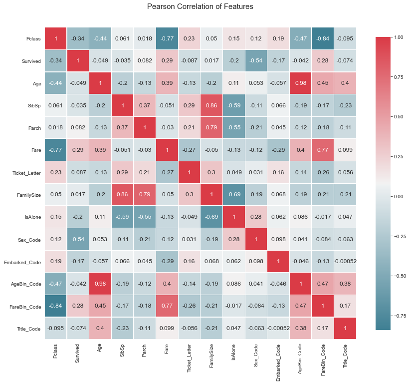

```python
def correlation_heatmap(df):
    _ , ax = plt.subplots(figsize =(14, 12))
    colormap = sns.diverging_palette(220, 10, as_cmap = True)

    _ = sns.heatmap(
        df.corr(),
        cmap = colormap,
        square=True,
        cbar_kws={'shrink':.9 },
        ax=ax,
        annot=True,
        linewidths=0.1,vmax=1.0, linecolor='white',
        annot_kws={'fontsize':12 }
    )

    plt.title('Pearson Correlation of Features', y=1.05, size=15)

correlation_heatmap(dataset)
```

# Modeling

In this step, we are going to,

1. Split data into datasets
2. Choose the best models for ensemble
3. Hyper Parameter Tuning
4. Ensemble Models by hard and soft voting

## Split data into datasets

```python
# Double check the data
dataset.info()
```

```
<class 'pandas.core.frame.DataFrame'>
RangeIndex: 1309 entries, 0 to 1308
Data columns (total 19 columns):
 #   Column         Non-Null Count  Dtype
---  ------         --------------  -----
 0   Pclass         1309 non-null   int64
 1   Survived       891 non-null    float64
 2   Sex            1309 non-null   object
 3   Age            1309 non-null   float64
 4   SibSp          1309 non-null   int64
 5   Parch          1309 non-null   int64
 6   Fare           1309 non-null   float64
 7   Embarked       1309 non-null   object
 8   Ticket_Letter  1309 non-null   int64
 9   FamilySize     1309 non-null   int64
 10  IsAlone        1309 non-null   int64
 11  Title          1309 non-null   object
 12  FareBin        1309 non-null   category
 13  AgeBin         1309 non-null   category
 14  Sex_Code       1309 non-null   int64
 15  Embarked_Code  1309 non-null   int64
 16  AgeBin_Code    1309 non-null   int64
 17  FareBin_Code   1309 non-null   int64
 18  Title_Code     1309 non-null   int64
dtypes: category(2), float64(3), int64(11), object(3)
memory usage: 177.5+ KB
```

```python
#Category variables by column names

#define y variable
Target = ['Survived']

#define x variables for original variables
dataset_x = ['Pclass', 'Sex', 'Age', 'SibSp', 'Parch', 'Fare', 'Embarked', 'Ticket_Letter', 'FamilySize', 'IsAlone', 'Title']#for draw charts
dataset_x_calc = ['Pclass', 'Sex_Code', 'AgeBin_Code', 'SibSp', 'Parch', 'FareBin_Code', 'Embarked_Code','Ticket_Letter', 'FamilySize', 'IsAlone','Title_Code'] #For algorithm calculation
dataset_xy = Target + dataset_x

print('Original Y X: ', dataset_xy, '\n')

#define x variables for original w/bin features to remove continous variables
dataset_bin_x = ['Pclass', 'Sex_Code', 'AgeBin_Code', 'SibSp', 'Parch', 'FareBin_Code', 'Embarked_Code','Ticket_Letter', 'FamilySize', 'IsAlone','Title_Code']
dataset_bin_xy = Target + dataset_bin_x
print('Bin Y X: ', dataset_bin_xy, '\n')


#define x and y variables for dummy features original
#train_data_dummy = pd.get_dummies(train_data_raw[train_data_x])
#train_data_dummy_x = train_data_dummy.columns.tolist()
#train_data_dummy_xy = Target + train_data_dummy_x
#print('Dummy X Y: ', train_data_dummy_xy, '\n')

#train_data_dummy.head()
```

```
Original Y X:  ['Survived', 'Pclass', 'Sex', 'Age', 'SibSp', 'Parch', 'Fare', 'Embarked', 'Ticket_Letter', 'FamilySize', 'IsAlone', 'Title']

Bin Y X:  ['Survived', 'Pclass', 'Sex_Code', 'AgeBin_Code', 'SibSp', 'Parch', 'FareBin_Code', 'Embarked_Code', 'Ticket_Letter', 'FamilySize', 'IsAlone', 'Title_Code']
```

```python
#Split data into train and test data, x and y
train_data = dataset.iloc[:train_len,:]
test_data = dataset.iloc[train_len:,:]
test_data.drop('Survived', axis=1, inplace=True)
```

```python
train_x = train_data[dataset_bin_x]
train_y = train_data['Survived'].astype(int)
test_x = test_data[dataset_bin_x]
```

## Choose the best models for ensemble

```python
#Code reference: https://www.kaggle.com/ldfreeman3/a-data-science-framework-to-achieve-99-accuracy/
np.random.seed(11)

cv_split = model_selection.ShuffleSplit(n_splits = 10, test_size = .3, train_size = .6, random_state = 0 ) # run model 10x with 60/30 split intentionally leaving out 10%

MLA = [
    #Ensemble Methods
    AdaBoostClassifier(),
    BaggingClassifier(),
    GradientBoostingClassifier(),
    RandomForestClassifier(),

    #GLM
    linear_model.LogisticRegressionCV(),

    #Discriminant Analysis
    discriminant_analysis.LinearDiscriminantAnalysis(),
    discriminant_analysis.QuadraticDiscriminantAnalysis(),


    #Nearest Neighbor
    neighbors.KNeighborsClassifier(),

    #SVM
    svm.SVC(probability=True),

    #Trees
    tree.DecisionTreeClassifier(),
    ]


#create table to compare MLA metrics
MLA_columns = ['MLA Name', 'MLA Parameters','MLA Train Accuracy Mean', 'MLA Test Accuracy Mean', 'MLA Test Accuracy 3*STD' ,'MLA Time']
MLA_compare = pd.DataFrame(columns = MLA_columns)

#create table to compare MLA predictions
MLA_predict = train_data[Target]

#index through MLA and save performance to table
row_index = 0
for alg in MLA:

    #set name and parameters
    MLA_name = alg.__class__.__name__
    MLA_compare.loc[row_index, 'MLA Name'] = MLA_name
    MLA_compare.loc[row_index, 'MLA Parameters'] = str(alg.get_params())

    #score model with cross validation: http://scikit-learn.org/stable/modules/generated/sklearn.model_selection.cross_validate.html#sklearn.model_selection.cross_validate
    cv_results = model_selection.cross_validate(alg, train_x, train_y, cv  = cv_split, return_train_score=True )

    MLA_compare.loc[row_index, 'MLA Time'] = cv_results['fit_time'].mean()
    MLA_compare.loc[row_index, 'MLA Train Accuracy Mean'] = cv_results['train_score'].mean()
    MLA_compare.loc[row_index, 'MLA Test Accuracy Mean'] = cv_results['test_score'].mean()
    #if this is a non-bias random sample, then +/-3 standard deviations (std) from the mean, should statistically capture 99.7% of the subsets
    MLA_compare.loc[row_index, 'MLA Test Accuracy 3*STD'] = cv_results['test_score'].std()*3   #let's know the worst that can happen!
    #let's know the worst that can happen!

    #save MLA predictions - see section 6 for usage
    alg.fit(train_x, train_y)
    MLA_predict[MLA_name] = alg.predict(train_x)

    row_index+=1

#print and sort table: https://pandas.pydata.org/pandas-docs/stable/generated/pandas.DataFrame.sort_values.html
MLA_compare.sort_values(by = ['MLA Test Accuracy Mean'], ascending = False, inplace = True)
MLA_compare
#MLA_predict
```

|  | MLA Name | MLA Parameters | MLA Train Accuracy Mean | MLA Test Accuracy Mean | MLA Test Accuracy 3*STD | MLA Time |
| --- | --- | --- | --- | --- | --- | --- |
| 2 | GradientBoostingClassifier | {'ccp_alpha': 0.0, 'criterion': 'friedman_mse'... | 0.889139 | 0.830597 | 0.0666397 | 0.064078 |
| 8 | SVC | {'C': 1.0, 'break_ties': False, 'cache_size': ... | 0.834644 | 0.824254 | 0.0586913 | 0.0229652 |
| 0 | AdaBoostClassifier | {'algorithm': 'SAMME.R', 'base_estimator': Non... | 0.839513 | 0.821642 | 0.080223 | 0.0507987 |
| 3 | RandomForestClassifier | {'bootstrap': True, 'ccp_alpha': 0.0, 'class_w... | 0.946255 | 0.815299 | 0.0442837 | 0.106135 |
| 1 | BaggingClassifier | {'base_estimator': None, 'bootstrap': True, 'b... | 0.936891 | 0.811567 | 0.0508682 | 0.0169121 |
| 4 | LogisticRegressionCV | {'Cs': 10, 'class_weight': None, 'cv': None, '... | 0.817978 | 0.809701 | 0.0546103 | 0.256425 |
| 5 | LinearDiscriminantAnalysis | {'n_components': None, 'priors': None, 'shrink... | 0.818727 | 0.802612 | 0.0540221 | 0.00217571 |
| 9 | DecisionTreeClassifier | {'ccp_alpha': 0.0, 'class_weight': None, 'crit... | 0.946255 | 0.796642 | 0.042552 | 0.00191376 |
| 7 | KNeighborsClassifier | {'algorithm': 'auto', 'leaf_size': 30, 'metric... | 0.840824 | 0.781343 | 0.069403 | 0.00170171 |
| 6 | QuadraticDiscriminantAnalysis | {'priors': None, 'reg_param': 0.0, 'store_cova... | 0.753371 | 0.738433 | 0.180043 | 0.00160637 |

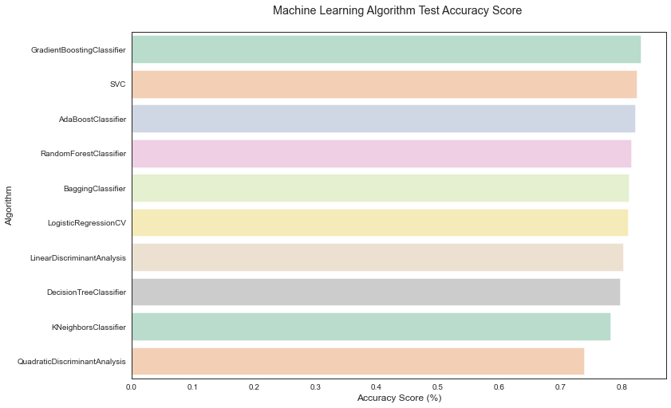

```python
sns.barplot(x='MLA Test Accuracy Mean', y = 'MLA Name', data = MLA_compare, palette="Pastel2")
plt.title('Machine Learning Algorithm Test Accuracy Score \n')
plt.xlabel('Accuracy Score (%)')
plt.ylabel('Algorithm')
```

The top 5 score models: Gradient Boosting, Support Vector Mapping Convergence, AdaBoost, Random Forest, and Bagging were selected for ensemble.

## Hyper Parameter Tuning

The hyper parameter tuning was conducted to select the best parameters for each model. There are 30% train data were used for testing, 60% train data were used for training, 10% train data were ignored in the 10-fold cross validation. The best scores for the five tuned models are 0.8116, 0.8313, 0.8037, 0.8399, 0.8332.

```python
np.random.seed(11)

score_list = []

# 1) Gradient boosting tunning
GB = GradientBoostingClassifier()

GB = model_selection.GridSearchCV(GB, param_grid = {'loss' : ["deviance"],
                                       'n_estimators' : [10, 20, 50, 100, 300],
                                       'learning_rate': [0.01, 0.05, 0.1, 0.25],
                                       'max_depth': [4, 8],
                                       'min_samples_leaf': [100,150],
                                       'max_features': [0.3, 0.1] }, cv=cv_split, scoring="accuracy", n_jobs= 8, verbose = 1)

GB.fit(train_x, train_y)

score_list.append(GB.best_score_)

print('Best Parameters: ', GB.best_params_)
print('Best Score: ', GB.best_score_)
```

```
Fitting 10 folds for each of 160 candidates, totalling 1600 fits
```

```
[Parallel(n_jobs=8)]: Using backend LokyBackend with 8 concurrent workers.
[Parallel(n_jobs=8)]: Done  64 tasks      | elapsed:    0.5s
[Parallel(n_jobs=8)]: Done 656 tasks      | elapsed:    4.5s
[Parallel(n_jobs=8)]: Done 1585 out of 1600 | elapsed:   11.9s remaining:    0.1s
[Parallel(n_jobs=8)]: Done 1600 out of 1600 | elapsed:   12.0s finished
```

```
Best Parameters:  {'learning_rate': 0.25, 'loss': 'deviance', 'max_depth': 8, 'max_features': 0.3, 'min_samples_leaf': 100, 'n_estimators': 300}
Best Score:  0.8115671641791046
```

```python
np.random.seed(11)

# 2) SVMC tunning
SVMC = svm.SVC(probability=True)

SVMC = model_selection.GridSearchCV(SVMC,param_grid = {'kernel': ['rbf'],
                                                         'gamma': [ 0.001, 0.01, 0.1, 1],
                                                         'C': [1, 10, 50, 100,200,300, 1000]}, cv=cv_split, scoring="accuracy", n_jobs= 8, verbose = 1)

SVMC.fit(train_x,train_y)

score_list.append(SVMC.best_score_)

print('Best Parameters: ', SVMC.best_params_)
print('Best Score: ', SVMC.best_score_)
```

```
Fitting 10 folds for each of 28 candidates, totalling 280 fits
```

```
[Parallel(n_jobs=8)]: Using backend LokyBackend with 8 concurrent workers.
[Parallel(n_jobs=8)]: Done  56 tasks      | elapsed:    0.6s
```

```
Best Parameters:  {'C': 10, 'gamma': 0.01, 'kernel': 'rbf'}
Best Score:  0.8313432835820895
```

```
[Parallel(n_jobs=8)]: Done 280 out of 280 | elapsed:    3.9s finished
```

```python
np.random.seed(11)

# 3) AdaBoost tunning
# Ref. https://www.cnblogs.com/pinard/p/6136914.html

DT = DecisionTreeClassifier()

adaDT = AdaBoostClassifier(DT, random_state=7)

ada_param_grid = {"base_estimator__criterion" : ["gini", "entropy"],
              "base_estimator__splitter" :   ["best", "random"],
              "algorithm" : ["SAMME","SAMME.R"],
              "n_estimators" :[1,2],
              "learning_rate":  [0.0001, 0.001, 0.01, 0.1, 0.2, 0.3,1.5]}

adaDT = model_selection.GridSearchCV(adaDT,param_grid = ada_param_grid, cv=cv_split, scoring="accuracy", n_jobs= 8, verbose = 1)

adaDT.fit(train_x,train_y)

score_list.append(adaDT.best_score_)

print('Best Parameters: ', adaDT.best_params_)
print('Best Score: ', adaDT.best_score_)
```

```
Fitting 10 folds for each of 112 candidates, totalling 1120 fits
```

```
[Parallel(n_jobs=8)]: Using backend LokyBackend with 8 concurrent workers.
[Parallel(n_jobs=8)]: Done  56 tasks      | elapsed:    0.2s
```

```
Best Parameters:  {'algorithm': 'SAMME.R', 'base_estimator__criterion': 'gini', 'base_estimator__splitter': 'best', 'learning_rate': 0.2, 'n_estimators': 2}
Best Score:  0.8037313432835822
```

```
[Parallel(n_jobs=8)]: Done 1096 tasks      | elapsed:    1.8s
[Parallel(n_jobs=8)]: Done 1120 out of 1120 | elapsed:    1.9s finished
```

```python
np.random.seed(11)

# 4) Random Forest tunning
RF = RandomForestClassifier()

RF = model_selection.GridSearchCV(RF, param_grid = {"max_depth": [None],
                                                    "oob_score": [True],
                                    "max_features": [1, 3, 10],
                                    "min_samples_split": [2, 3, 10],
                                    "n_estimators" :[10, 20, 50, 100, 300],
                                    "criterion": ["gini"]}, cv=cv_split, scoring="accuracy", n_jobs= 8, verbose = 1)
RF.fit(train_x,train_y)

score_list.append(RF.best_score_)

print('Best Parameters: ', RF.best_params_)
print('Best Score: ', RF.best_score_)
```

```
Fitting 10 folds for each of 45 candidates, totalling 450 fits
```

```
[Parallel(n_jobs=8)]: Using backend LokyBackend with 8 concurrent workers.
[Parallel(n_jobs=8)]: Done  34 tasks      | elapsed:    3.6s
[Parallel(n_jobs=8)]: Done 184 tasks      | elapsed:    8.6s
```

```
Best Parameters:  {'criterion': 'gini', 'max_depth': None, 'max_features': 10, 'min_samples_split': 10, 'n_estimators': 100, 'oob_score': True}
Best Score:  0.8399253731343285
```

```
[Parallel(n_jobs=8)]: Done 450 out of 450 | elapsed:   18.8s finished
```

```python
np.random.seed(11)

# 5) Bagging tunning
BG = BaggingClassifier()
BG = model_selection.GridSearchCV(BG, param_grid = {'n_estimators':[10, 20, 50, 100, 300],
                                                   'max_samples': [.1, .25, .5, .75, 1.0],
                                                   'oob_score': [True, False],
                                                   'random_state': [0]}, scoring = 'accuracy', cv = cv_split, n_jobs= 8)
BG.fit(train_x,train_y)

score_list.append(BG.best_score_)

print('Best Parameters: ', BG.best_params_)
print('Best Score: ', BG.best_score_)
```

```
Best Parameters:  {'max_samples': 0.25, 'n_estimators': 100, 'oob_score': True, 'random_state': 0}
Best Score:  0.8332089552238806
```

```python
score_list
```

```
[0.8115671641791046,
 0.8313432835820895,
 0.8037313432835822,
 0.8399253731343285,
 0.8332089552238806]
```

## Ensemble Models by hard and soft voting

In the importance feature analysis, the first two important features for Gradient Boosting, AdaBoost, and Random Forest are same: Sex and Fare. In the correlation analysis, the predicted results of the five models are highly correlated but they are also different.

The 5 models were ensembled. First, the 5 models were ensembled by both hard and soft voting. Then, the accuracy scores were calculated for two models though cross validation. The accuracy score for soft voting is 0.8328, which is higher than the score of hard voting that is 0.8325. Therefore, the soft voting was chosen to predict the test dataset.

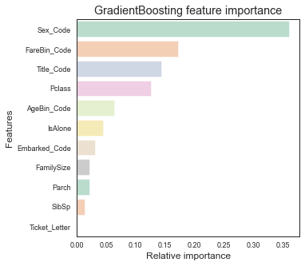

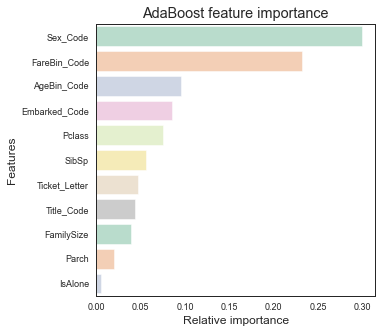

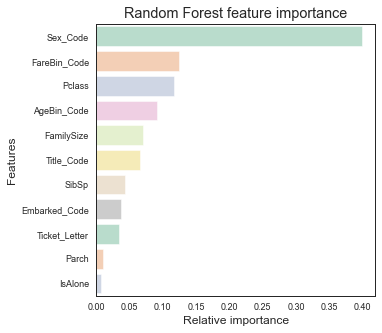

```python
names_classifiers = [("GradientBoosting",GB.best_estimator_),("AdaBoost", adaDT.best_estimator_),("Random Forest",RF.best_estimator_)]

for i in range(3):
    name = names_classifiers[i][0]
    classifier = names_classifiers[i][1]
    plt.subplots(figsize=(5,5))
    indices = np.argsort(classifier.feature_importances_)[::-1][:40]
    g = sns.barplot(y=train_x.columns[indices][:40],x = classifier.feature_importances_[indices][:40] , orient='h',palette="Pastel2")
    g.set_xlabel("Relative importance",fontsize=12)
    g.set_ylabel("Features",fontsize=12)
    g.tick_params(labelsize=9)
    g.set_title(name + " feature importance")
    plt.show()
```

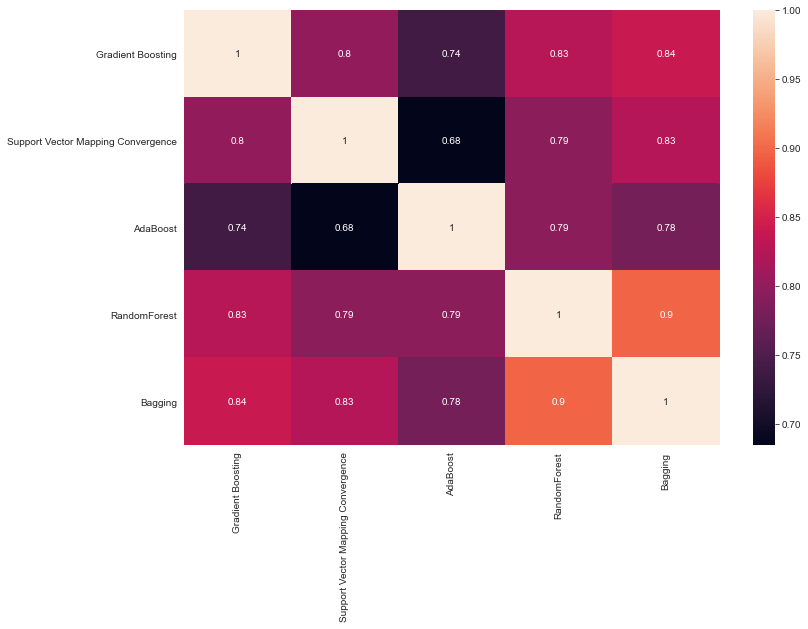

```python
test_Survived_GB = pd.Series(GB.predict(test_x), name="Gradient Boosting")
test_Survived_SVMC = pd.Series(SVMC.predict(test_x), name="Support Vector Mapping Convergence")
test_Survived_Ada = pd.Series(adaDT.predict(test_x), name="AdaBoost")
test_Survived_RF = pd.Series(RF.predict(test_x), name="RandomForest")
test_Survived_BG = pd.Series(BG.predict(test_x), name="Bagging")

# Concatenate all classifier results
ensemble_results = pd.concat([test_Survived_GB,test_Survived_SVMC,test_Survived_Ada,test_Survived_RF, test_Survived_BG],axis=1)


g= sns.heatmap(ensemble_results.corr(),annot=True)
```

```python
voting_hard = VotingClassifier(estimators=[('GB',GB.best_estimator_),('SVMC',SVMC.best_estimator_),('Ada', adaDT.best_estimator_),
                               ('RF', RF.best_estimator_), ('BG',BG.best_estimator_)], voting='hard', n_jobs=8)
voting_hard = voting_hard.fit(train_x, train_y)
```

```python
cv_results_hard_voting = model_selection.cross_validate(voting_hard, train_x, train_y, cv  = cv_split, return_train_score=True )
print(cv_results_hard_voting['test_score'].mean())
```

```
0.8324626865671643
```

```python
voting_soft = VotingClassifier(estimators=[('GB',GB.best_estimator_),('SVMC',SVMC.best_estimator_),('Ada', adaDT.best_estimator_),
                               ('RF', RF.best_estimator_), ('BG',BG.best_estimator_)], voting='soft', n_jobs=8)
voting_soft = voting_soft.fit(train_x, train_y)
```

```python
cv_results_soft_voting = model_selection.cross_validate(voting_soft, train_x, train_y, cv  = cv_split, return_train_score=True )
print(cv_results_soft_voting['test_score'].mean())
```

```
0.8328358208955224
```

# Prediction and Submission

The soft voting were chosen to predict the survival in test dataset.

```python
find_test_id = pd.read_csv("titanic/test.csv")
test_data['PassengerId'] = find_test_id['PassengerId'].tolist()
```

```python
test_data['Survived'] = voting_soft.predict(test_x)
prediction_submit = test_data[['PassengerId','Survived']]
prediction_submit.to_csv("submit_vote_soft_1219v1.csv", index=False)
```